# Proposal

William Han, Christopher Soong, Matthew Jung, Daun Kim

10/21/2021

# Introduction

In our continually evolving world of technology, the threat of cyber attacks grows with each day. Security breaches and data leaks are becoming more and more common, such as the Accellion data leak that affected the UC system earlier this year.

With a successful cyber attack on a hospital, the attacker not only has access to medical information, but can tamper with it in any way they see fit. Aside from a severe invasion of privacy, alterations to patients’ information could lead to further misdiagnosis, falsificaiton of medical history for a patient’s benefit or hinderance, or even identity theft. This opens up a realm of possibilities for the attacker, giving them full control over patients’ livelihood.

The data presents just one hypothetical example of what a cyber attack can do to medical information. As people’s lives are at risk, being able to identify Deepfake tampered images of cancer is of utmost importance.

Consequently, there will be 3 main questions that team 12 would like to find out through this data set.

1. What is the accuracy of diagnosis between doctors and artificial intelligence systems?
2. What is the extent of influence between open and blind trials in diagnosis given by doctors?
3. Does higher confidence in doctors give a more accurate diagnosis?

# Data

Dataset: https://archive.ics.uci.edu/ml/datasets/Deepfakes%3A+Medical+Image+Tamper+Detection

```
## archive.ics.uci.edu
```

```
## [1] TRUE
```

```r
glimpse(exp1_known_AI_instances)
```

```
## Rows: 133
## Columns: 8
## $ type          <chr> "FB", "FB", "FB", "FB", "FB", "FB", "FB", "FB", "FB", "F…
## $ uuid          <dbl> 1280, 1009, 7794, 7794, 2997, 2997, 2997, 2997, 2997, 20…
## $ slice         <dbl> 100, 76, 79, 94, 45, 52, 63, 70, 81, 208, 298, 299, 494,…
## $ x             <dbl> 323, 354, 163, 338, 156, 179, 156, 85, 418, 42, 150, 59,…
## $ y             <dbl> 381, 288, 191, 243, 135, 370, 260, 197, 184, 269, 99, 29…
## $ detected      <lgl> FALSE, FALSE, FALSE, FALSE, FALSE, FALSE, FALSE, FALSE, …
## $ detected_diam <dbl> 0.000000, 0.000000, 0.000000, 0.000000, 0.000000, 0.0000…
## $ label         <lgl> TRUE, TRUE, TRUE, TRUE, TRUE, TRUE, TRUE, TRUE, TRUE, TR…
```

```r
glimpse(exp1_known_AI_patients)
```

```
## Rows: 80
## Columns: 13
## $ id                <dbl> 1003, 1005, 1009, 1045, 1067, 1201, 1219, 1280, 1356…
## $ type              <chr> "FM", "FM", "FB", "TM", "FB", "FM", "FB", "FB", "FB"…
## $ label             <lgl> FALSE, FALSE, TRUE, TRUE, TRUE, FALSE, TRUE, TRUE, T…
## $ prediction        <lgl> TRUE, TRUE, FALSE, TRUE, FALSE, TRUE, TRUE, FALSE, F…
## $ n_instances       <dbl> 2, 1, 1, 1, 1, 1, 2, 1, 1, 3, 1, 1, 1, 1, 4, 1, 3, 1…
## $ n_detected        <dbl> 2, 1, 0, 1, 0, 1, 1, 0, 0, 1, 0, 1, 1, 0, 0, 1, 3, 0…
## $ n_missed          <dbl> 0, 0, 1, 0, 1, 0, 1, 1, 1, 2, 1, 0, 0, 1, 4, 0, 0, 1…
## $ n_succ            <dbl> 2, 1, 1, NA, 1, 1, 1, 1, 1, 2, 1, 1, 1, NA, 4, NA, 3…
## $ r_succ            <dbl> 1.0000000, 1.0000000, 1.0000000, NA, 1.0000000, 1.00…
## $ n_fail            <dbl> 0, 0, 0, NA, 0, 0, 1, 0, 0, 1, 0, 0, 0, NA, 0, NA, 0…
## $ r_fail            <dbl> 0.0000000, 0.0000000, 0.0000000, NA, 0.0000000, 0.00…
## $ misdiagnosed      <lgl> TRUE, TRUE, TRUE, FALSE, TRUE, TRUE, TRUE, TRUE, TRU…
## $ baseline_accuracy <dbl> NA, NA, NA, 1, NA, NA, NA, NA, NA, NA, NA, NA, NA, 1…
```

```r
glimpse(exp1_known_reviewer1_instances)
```

```
## Rows: 133
## Columns: 8
## $ type          <chr> "FB", "FB", "FB", "FB", "FB", "FB", "FB", "FB", "FB", "F…
## $ uuid          <dbl> 1280, 1009, 7794, 7794, 2997, 2997, 2997, 2997, 2997, 20…
## $ slice         <dbl> 100, 76, 79, 94, 45, 52, 63, 70, 81, 208, 298, 299, 494,…
## $ x             <dbl> 323, 354, 163, 338, 156, 179, 156, 85, 418, 42, 150, 59,…
## $ y             <dbl> 381, 288, 191, 243, 135, 370, 260, 197, 184, 269, 99, 29…
## $ detected      <lgl> FALSE, FALSE, FALSE, FALSE, FALSE, TRUE, FALSE, FALSE, F…
## $ detected_diam <dbl> 0, 0, 0, 0, 0, 3, 0, 0, 0, 0, 0, 0, 0, 0, 0, 9, 0, 0, 0,…
## $ label         <lgl> TRUE, TRUE, TRUE, TRUE, TRUE, TRUE, TRUE, TRUE, TRUE, TR…
```

```r
glimpse(exp1_known_reviewer1_patients)
```

```
## Rows: 80
## Columns: 13
## $ id                <dbl> 1003, 1005, 1009, 1045, 1067, 1201, 1219, 1280, 1356…
## $ type              <chr> "FM", "FM", "FB", "TM", "FB", "FM", "FB", "FB", "FB"…
## $ label             <lgl> FALSE, FALSE, TRUE, TRUE, TRUE, FALSE, TRUE, TRUE, T…
## $ prediction        <lgl> TRUE, TRUE, FALSE, TRUE, FALSE, FALSE, FALSE, FALSE,…
## $ n_instances       <dbl> 2, 1, 1, 1, 1, 1, 2, 1, 1, 3, 1, 1, 1, 1, 4, 1, 3, 1…
## $ n_detected        <dbl> 1, 1, 0, 1, 0, 0, 0, 0, 0, 0, 0, 1, 1, 0, 0, 1, 3, 0…
## $ n_missed          <dbl> 1, 0, 1, 0, 1, 1, 2, 1, 1, 3, 1, 0, 0, 1, 4, 0, 0, 1…
## $ n_succ            <dbl> 1, 1, 1, NA, 1, 0, 2, 1, 1, 3, 1, 1, 1, NA, 4, NA, 3…
## $ r_succ            <dbl> 0.5, 1.0, 1.0, NA, 1.0, 0.0, 1.0, 1.0, 1.0, 1.0, 1.0…
## $ n_fail            <dbl> 1, 0, 0, NA, 0, 1, 0, 0, 0, 0, 0, 0, 0, NA, 0, NA, 0…
## $ r_fail            <dbl> 0.5, 0.0, 0.0, NA, 0.0, 1.0, 0.0, 0.0, 0.0, 0.0, 0.0…
## $ misdiagnosed      <lgl> TRUE, TRUE, TRUE, FALSE, TRUE, FALSE, TRUE, TRUE, TR…
## $ baseline_accuracy <dbl> NA, NA, NA, 1, NA, NA, NA, NA, NA, NA, NA, NA, NA, 1…
```

```r
glimpse(exp1_known_reviewer2_instances)
```

```
## Rows: 133
## Columns: 8
## $ type          <chr> "FB", "FB", "FB", "FB", "FB", "FB", "FB", "FB", "FB", "F…
## $ uuid          <dbl> 1280, 1009, 7794, 7794, 2997, 2997, 2997, 2997, 2997, 20…
## $ slice         <dbl> 100, 76, 79, 94, 45, 52, 63, 70, 81, 208, 298, 299, 494,…
## $ x             <dbl> 323, 354, 163, 338, 156, 179, 156, 85, 418, 42, 150, 59,…
## $ y             <dbl> 381, 288, 191, 243, 135, 370, 260, 197, 184, 269, 99, 29…
## $ detected      <lgl> FALSE, FALSE, FALSE, FALSE, FALSE, FALSE, FALSE, FALSE, …
## $ detected_diam <dbl> 0.0, 0.0, 0.0, 0.0, 0.0, 0.0, 0.0, 0.0, 0.0, 0.0, 0.0, 0…
## $ label         <lgl> TRUE, TRUE, TRUE, TRUE, TRUE, TRUE, TRUE, TRUE, TRUE, TR…
```

```r
glimpse(exp1_known_reviewer2_patients)
```

```
## Rows: 80
## Columns: 13
## $ id                <dbl> 1003, 1005, 1009, 1045, 1067, 1201, 1219, 1280, 1356…
## $ type              <chr> "FM", "FM", "FB", "TM", "FB", "FM", "FB", "FB", "FB"…
## $ label             <lgl> FALSE, FALSE, TRUE, TRUE, TRUE, FALSE, TRUE, TRUE, T…
## $ prediction        <lgl> TRUE, TRUE, FALSE, TRUE, FALSE, TRUE, FALSE, FALSE, …
## $ n_instances       <dbl> 2, 1, 1, 1, 1, 1, 2, 1, 1, 3, 1, 1, 1, 1, 4, 1, 3, 1…
## $ n_detected        <dbl> 2, 1, 0, 1, 0, 1, 0, 0, 1, 0, 0, 1, 1, 0, 0, 1, 2, 0…
## $ n_missed          <dbl> 0, 0, 1, 0, 1, 0, 2, 1, 0, 3, 1, 0, 0, 1, 4, 0, 1, 1…
## $ n_succ            <dbl> 2, 1, 1, NA, 1, 1, 2, 1, 0, 3, 1, 1, 1, NA, 4, NA, 2…
## $ r_succ            <dbl> 1.0000000, 1.0000000, 1.0000000, NA, 1.0000000, 1.00…
## $ n_fail            <dbl> 0, 0, 0, NA, 0, 0, 0, 0, 1, 0, 0, 0, 0, NA, 0, NA, 1…
## $ r_fail            <dbl> 0.0000000, 0.0000000, 0.0000000, NA, 0.0000000, 0.00…
## $ misdiagnosed      <lgl> TRUE, TRUE, TRUE, FALSE, TRUE, TRUE, TRUE, TRUE, FAL…
## $ baseline_accuracy <dbl> NA, NA, NA, 1.00, NA, NA, NA, NA, NA, NA, NA, NA, NA…
```

```r
glimpse(exp1_known_reviewer3_instances)
```

```
## Rows: 133
## Columns: 8
## $ type          <chr> "FB", "FB", "FB", "FB", "FB", "FB", "FB", "FB", "FB", "F…
## $ uuid          <dbl> 1280, 1009, 7794, 7794, 2997, 2997, 2997, 2997, 2997, 20…
## $ slice         <dbl> 100, 76, 79, 94, 45, 52, 63, 70, 81, 208, 298, 299, 494,…
## $ x             <dbl> 323, 354, 163, 338, 156, 179, 156, 85, 418, 42, 150, 59,…
## $ y             <dbl> 381, 288, 191, 243, 135, 370, 260, 197, 184, 269, 99, 29…
## $ detected      <lgl> FALSE, FALSE, FALSE, FALSE, FALSE, FALSE, FALSE, FALSE, …
## $ detected_diam <dbl> 0.0, 0.0, 0.0, 0.0, 0.0, 0.0, 0.0, 0.0, 0.0, 0.0, 0.0, 0…
## $ label         <lgl> TRUE, TRUE, TRUE, TRUE, TRUE, TRUE, TRUE, TRUE, TRUE, TR…
```

```r
glimpse(exp1_known_reviewer3_patients)
```

```
## Rows: 80
## Columns: 13
## $ id                <dbl> 1003, 1005, 1009, 1045, 1067, 1201, 1219, 1280, 1356…
## $ type              <chr> "FM", "FM", "FB", "TM", "FB", "FM", "FB", "FB", "FB"…
## $ label             <lgl> FALSE, FALSE, TRUE, TRUE, TRUE, FALSE, TRUE, TRUE, T…
## $ prediction        <lgl> TRUE, TRUE, FALSE, TRUE, TRUE, TRUE, FALSE, FALSE, F…
## $ n_instances       <dbl> 2, 1, 1, 1, 1, 1, 2, 1, 1, 3, 1, 1, 1, 1, 4, 1, 3, 1…
## $ n_detected        <dbl> 2, 1, 0, 1, 1, 1, 0, 0, 0, 0, 0, 1, 1, 0, 0, 1, 3, 0…
## $ n_missed          <dbl> 0, 0, 1, 0, 0, 0, 2, 1, 1, 3, 1, 0, 0, 1, 4, 0, 0, 1…
## $ n_succ            <dbl> 2, 1, 1, NA, 0, 1, 2, 1, 1, 3, 1, 1, 1, NA, 4, NA, 3…
## $ r_succ            <dbl> 1, 1, 1, NA, 0, 1, 1, 1, 1, 1, 1, 1, 1, NA, 1, NA, 1…
## $ n_fail            <dbl> 0, 0, 0, NA, 1, 0, 0, 0, 0, 0, 0, 0, 0, NA, 0, NA, 0…
## $ r_fail            <dbl> 0, 0, 0, NA, 1, 0, 0, 0, 0, 0, 0, 0, 0, NA, 0, NA, 0…
## $ misdiagnosed      <lgl> TRUE, TRUE, TRUE, FALSE, FALSE, TRUE, TRUE, TRUE, TR…
## $ baseline_accuracy <dbl> NA, NA, NA, 1, NA, NA, NA, NA, NA, NA, NA, NA, NA, 1…
```

```r
glimpse(exp2_unknown_reviewer1_instances)
```

```
## Rows: 36
## Columns: 10
## $ type          <chr> "FB", "FB", "FB", "FB", "FB", "FB", "FB", "FB", "FB", "F…
## $ uuid          <dbl> 1251, 1251, 1251, 2592, 1876, 7507, 7507, 6031, 6031, 60…
## $ slice         <dbl> 150, 188, 272, 163, 146, 319, 201, 64, 65, 51, 71, 331, …
## $ x             <dbl> 418, 402, 163, 230, 414, 125, 316, 240, 365, 119, 413, 1…
## $ y             <dbl> 350, 294, 298, 322, 181, 323, 362, 290, 395, 315, 336, 2…
## $ detected      <lgl> FALSE, FALSE, FALSE, FALSE, FALSE, FALSE, FALSE, FALSE, …
## $ detected_diam <dbl> 0, 0, 0, 0, 0, 0, 0, 0, 0, 0, 0, 0, 0, 13, 10, 14, 0, 0,…
## $ label         <lgl> TRUE, TRUE, TRUE, TRUE, TRUE, TRUE, TRUE, TRUE, TRUE, TR…
## $ prediction    <chr> "TB", "TB", "TB", "TB", "TB", "TB", "TB", "TB", "TB", "T…
## $ confidence    <dbl> 5, 5, 5, 5, 5, 5, 5, 5, 5, 5, 5, 5, 5, 4, 4, 4, 5, 5, 5,…
```

```r
glimpse(exp2_unknown_reviewer1_patients)
```

```
## Rows: 20
## Columns: 13
## $ id                <dbl> 1251, 1563, 1610, 1796, 1876, 2031, 2199, 2220, 2366…
## $ type              <chr> "FB", "TB", "TB", "FM", "FB", "FM", "TM", "TM", "TB"…
## $ label             <lgl> TRUE, FALSE, FALSE, FALSE, TRUE, FALSE, TRUE, TRUE, …
## $ prediction        <lgl> FALSE, FALSE, FALSE, TRUE, FALSE, TRUE, TRUE, FALSE,…
## $ n_instances       <dbl> 3, 1, 2, 2, 1, 1, 2, 2, 1, 3, 2, 1, 1, 3, 1, 1, 2, 1…
## $ n_detected        <dbl> 0, 0, 0, 0, 0, 1, 2, 0, 0, 2, 1, 1, 0, 3, 0, 0, 0, 1…
## $ n_missed          <dbl> 3, 1, 2, 2, 1, 0, 0, 2, 1, 1, 1, 0, 1, 0, 1, 1, 2, 0…
## $ n_succ            <dbl> 3, NA, NA, 0, 1, 1, NA, NA, NA, NA, NA, 1, 1, NA, NA…
## $ r_succ            <dbl> 1, NA, NA, 0, 1, 1, NA, NA, NA, NA, NA, 1, 1, NA, NA…
## $ n_fail            <dbl> 0, NA, NA, 2, 0, 0, NA, NA, NA, NA, NA, 0, 0, NA, NA…
## $ r_fail            <dbl> 0, NA, NA, 1, 0, 0, NA, NA, NA, NA, NA, 0, 0, NA, NA…
## $ misdiagnosed      <lgl> TRUE, FALSE, FALSE, TRUE, TRUE, TRUE, FALSE, TRUE, F…
## $ baseline_accuracy <dbl> NA, 1.0000000, 1.0000000, NA, NA, NA, 1.0000000, 0.0…
```

```r
glimpse(exp2_unknown_reviewer2_instances)
```

```
## Rows: 36
## Columns: 10
## $ type          <chr> "FB", "FB", "FB", "FB", "FB", "FB", "FB", "FB", "FB", "F…
## $ uuid          <dbl> 1251, 1251, 1251, 2592, 1876, 7507, 7507, 6031, 6031, 60…
## $ slice         <dbl> 150, 188, 272, 163, 146, 319, 201, 64, 65, 51, 71, 331, …
## $ x             <dbl> 418, 402, 163, 230, 414, 125, 316, 240, 365, 119, 413, 1…
## $ y             <dbl> 350, 294, 298, 322, 181, 323, 362, 290, 395, 315, 336, 2…
## $ detected      <lgl> FALSE, FALSE, TRUE, FALSE, TRUE, TRUE, FALSE, FALSE, TRU…
## $ detected_diam <dbl> 0.0, 0.0, 26.0, 0.0, 6.0, 19.0, 0.0, 0.0, 8.0, 0.0, 0.0,…
## $ label         <lgl> TRUE, TRUE, TRUE, TRUE, TRUE, TRUE, TRUE, TRUE, TRUE, TR…
## $ prediction    <chr> "TB", "TB", "FB", "TB", "FM", "FB", "TB", "TB", "TM", "T…
## $ confidence    <dbl> 5, 5, 5, 5, 2, 5, 5, 5, 4, 5, 5, 4, 4, 4, 2, 4, 4, 5, 5,…
```

```r
glimpse(exp2_unknown_reviewer2_patients)
```

```
## Rows: 20
## Columns: 13
## $ id                <dbl> 1251, 1563, 1610, 1796, 1876, 2031, 2199, 2220, 2366…
## $ type              <chr> "FB", "TB", "TB", "FM", "FB", "FM", "TM", "TM", "TB"…
## $ label             <lgl> TRUE, FALSE, FALSE, FALSE, TRUE, FALSE, TRUE, TRUE, …
## $ prediction        <lgl> TRUE, FALSE, FALSE, FALSE, TRUE, FALSE, TRUE, TRUE, …
## $ n_instances       <dbl> 3, 1, 2, 2, 1, 1, 2, 2, 1, 3, 2, 1, 1, 3, 1, 1, 2, 1…
## $ n_detected        <dbl> 1, 0, 0, 1, 1, 1, 2, 1, 0, 2, 2, 1, 0, 2, 0, 0, 2, 1…
## $ n_missed          <dbl> 2, 1, 2, 1, 0, 0, 0, 1, 1, 1, 0, 0, 1, 1, 1, 1, 0, 0…
## $ n_succ            <dbl> 2, NA, NA, 1, 0, 1, NA, NA, NA, NA, NA, 1, 1, NA, NA…
## $ r_succ            <dbl> 0.6666667, NA, NA, 0.5000000, 0.0000000, 1.0000000, …
## $ n_fail            <dbl> 1, NA, NA, 1, 1, 0, NA, NA, NA, NA, NA, 0, 0, NA, NA…
## $ r_fail            <dbl> 0.3333333, NA, NA, 0.5000000, 1.0000000, 0.0000000, …
## $ misdiagnosed      <lgl> FALSE, FALSE, FALSE, FALSE, TRUE, FALSE, FALSE, FALS…
## $ baseline_accuracy <dbl> NA, 1.0000000, 1.0000000, NA, NA, NA, 1.0000000, 0.5…
```

```r
glimpse(exp2_unknown_reviewer3_instances)
```

```
## Rows: 36
## Columns: 10
## $ type          <chr> "FB", "FB", "FB", "FB", "FB", "FB", "FB", "FB", "FB", "F…
## $ uuid          <dbl> 1251, 1251, 1251, 2592, 1876, 7507, 7507, 6031, 6031, 60…
## $ slice         <dbl> 150, 188, 272, 163, 146, 319, 201, 64, 65, 51, 71, 331, …
## $ x             <dbl> 418, 402, 163, 230, 414, 125, 316, 240, 365, 119, 413, 1…
## $ y             <dbl> 350, 294, 298, 322, 181, 323, 362, 290, 395, 315, 336, 2…
## $ detected      <lgl> FALSE, FALSE, FALSE, FALSE, FALSE, FALSE, FALSE, FALSE, …
## $ detected_diam <dbl> 0.0, 0.0, 0.0, 0.0, 0.0, 0.0, 0.0, 0.0, 7.0, 0.0, 0.0, 1…
## $ label         <lgl> TRUE, TRUE, TRUE, TRUE, TRUE, TRUE, TRUE, TRUE, TRUE, TR…
## $ prediction    <chr> "TB", "TB", "TB", "TB", "TB", "TB", "TB", "TB", "TM", "T…
## $ confidence    <dbl> 5, 5, 5, 5, 5, 5, 5, 5, 5, 5, 5, 3, 3, 2, 4, 3, 4, 2, 5,…
```

```r
glimpse(exp2_unknown_reviewer3_patients)
```

```
## Rows: 20
## Columns: 13
## $ id                <dbl> 1251, 1563, 1610, 1796, 1876, 2031, 2199, 2220, 2366…
## $ type              <chr> "FB", "TB", "TB", "FM", "FB", "FM", "TM", "TM", "TB"…
## $ label             <lgl> TRUE, FALSE, FALSE, FALSE, TRUE, FALSE, TRUE, TRUE, …
## $ prediction        <lgl> FALSE, FALSE, FALSE, FALSE, FALSE, TRUE, TRUE, TRUE,…
## $ n_instances       <dbl> 3, 1, 2, 2, 1, 1, 2, 2, 1, 3, 2, 1, 1, 3, 1, 1, 2, 1…
## $ n_detected        <dbl> 0, 0, 0, 2, 0, 1, 1, 1, 0, 2, 0, 1, 0, 2, 0, 0, 2, 1…
## $ n_missed          <dbl> 3, 1, 2, 0, 1, 0, 1, 1, 1, 1, 2, 0, 1, 1, 1, 1, 0, 0…
## $ n_succ            <dbl> 3, NA, NA, 2, 1, 1, NA, NA, NA, NA, NA, 1, 1, NA, NA…
## $ r_succ            <dbl> 1.00, NA, NA, 1.00, 1.00, 1.00, NA, NA, NA, NA, NA, …
## $ n_fail            <dbl> 0, NA, NA, 0, 0, 0, NA, NA, NA, NA, NA, 0, 0, NA, NA…
## $ r_fail            <dbl> 0.00, NA, NA, 0.00, 0.00, 0.00, NA, NA, NA, NA, NA, …
## $ misdiagnosed      <lgl> TRUE, FALSE, FALSE, FALSE, TRUE, TRUE, FALSE, FALSE,…
## $ baseline_accuracy <dbl> NA, 1.0000000, 1.0000000, NA, NA, NA, 0.5000000, 0.5…
```

# Data Analysis Plan

What is your primary variable of interest? (Response variable)

Accuracy(Diagnosis/Misdiagnosis)

What other variables (explanatory variables) will you be using to understand the response variable?

Doctor vs. AI (Categorical)

Blind Trial vs. Open Trial (Categorical)

Run preliminary analysis (including visuals and descriptive summary statistics) to get some idea about answers to your questions.

[figure not shown]

$$(\pi_D > \pi_A)
or
(\pi_D < \pi_A)$$

For this one experiment sample, the accuracy proportion of AI is 0.75, and the accuracy proportion of doctors is 0.7291667.

Therefore, we can analyze with this one sample that even though the accuracy proportion of AI is bigger than the accuracy proportion of doctors, the proportion of doctors’ accuracy is slightly different from the proportion of AI’s accuracy, so doctors are enough to be confident correct.

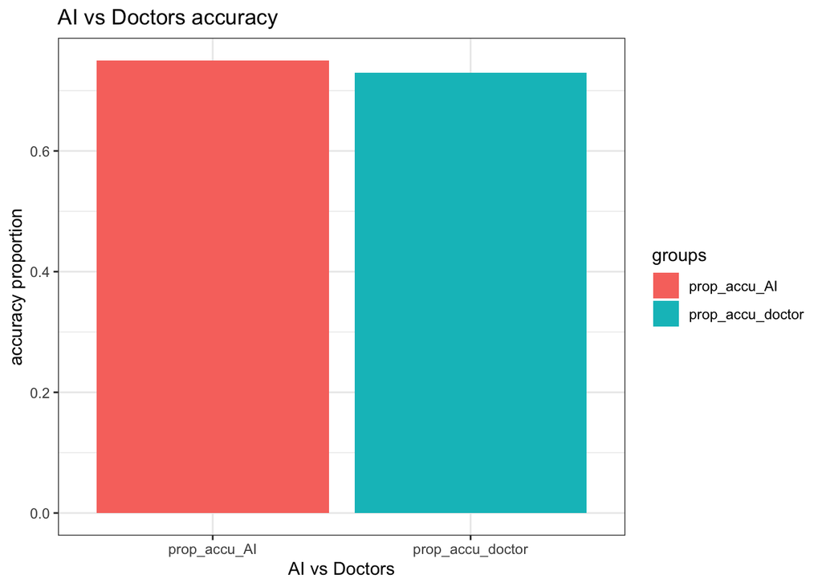

$$(\pi_B > \pi_O)
or
(\pi_B < \pi_O)$$

Therefore, we can analyze from these two experiments that doctors are more accurate when they know the data has been tampered with.

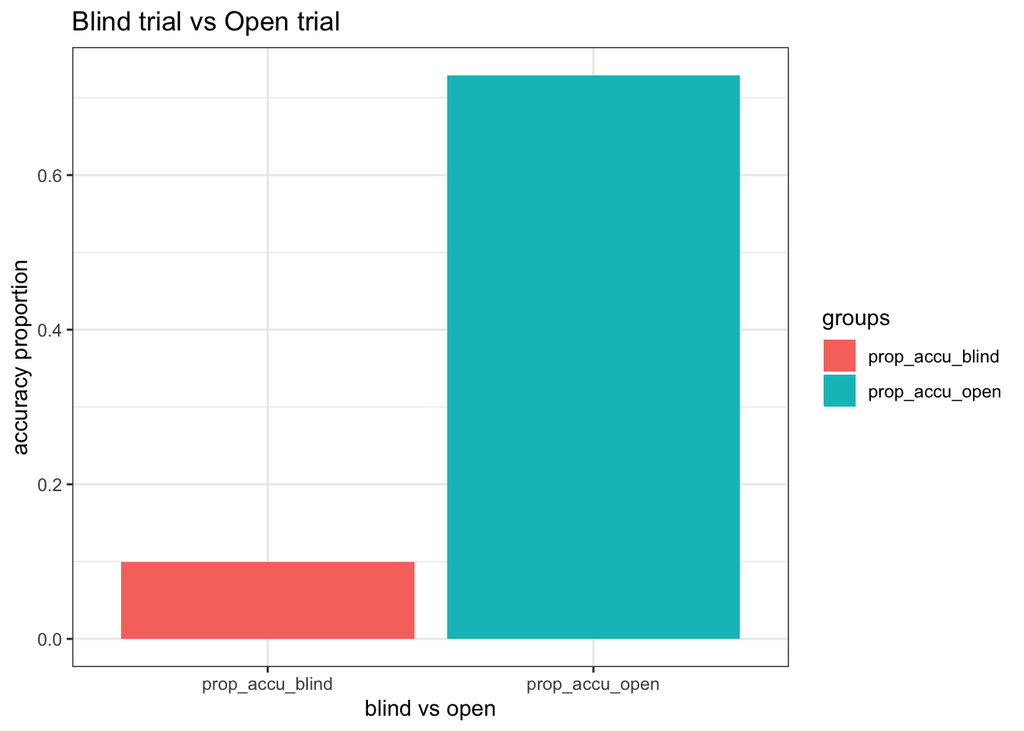